# Project: Investigate a Dataset - No-Show Appointments

### Does Alcoholism affect showing up for Appointments or not?

Let's investigate whether being alcohol dependent has an effect on the Patients' showing up for their Appointments or not.

Let's take a look at the Percentage of the Patients who have stated they are alcoholic or alcohol dependent.

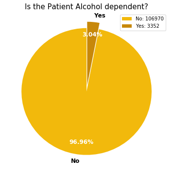

```python
plt.figure(figsize=[6,6])
_, _, at = plt.pie((df['alcoholism'].value_counts()), colors=['#F2B90C','#C7880A'], autopct='%.2f%%', explode=[0,0.1], pctdistance=0.8, startangle=90, labels=['No', 'Yes'], textprops={'fontsize':12,'color':'black', 'weight':'bold'});
for t in at:
    t.set_color('white')
plt.legend(labels=['No: 106970', 'Yes: 3352']);
plt.title('Is the Patient Alcohol dependent?', fontdict={'fontsize':15});
```

Looking at the Pie Chart above, we notice that the Percentage of alcohol dependent patients is relatively small.

Let's take a look at appointments' showing up and absence statistics.

```python
df.groupby(['alcoholism','shown_up']).count()['gender']
```

```
alcoholism  shown_up
0           0           21598
            1           85372
1           0             675
            1            2677
Name: gender, dtype: int64
```

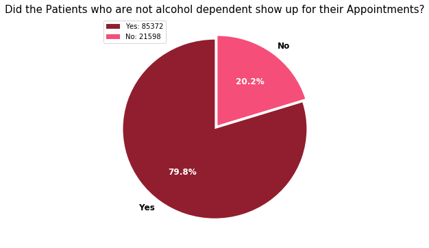

```python
plt.figure(figsize=[6,6])
_, _, at = plt.pie(df.groupby(['alcoholism','shown_up']).count()['gender'][0][::-1], labels=['Yes', 'No'], autopct='%.1f%%', colors=['#911e2e', '#f54e79'], startangle=90, explode=[0,0.05], textprops={'fontsize':12,'color':'black', 'weight':'bold'});
for t in at:
    t.set_color('white')
plt.legend(labels=['Yes: 85372', 'No: 21598']);
plt.title('Did the Patients who are not alcohol dependent show up for their Appointments?', fontdict={'fontsize':15});
```

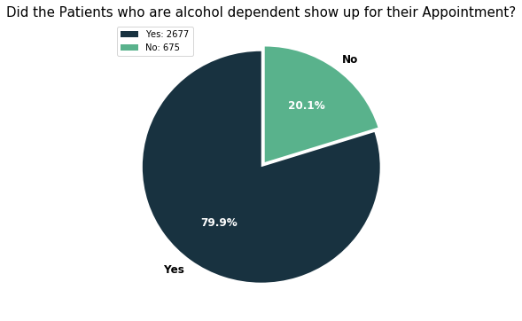

```python
plt.figure(figsize=[6,6])
_, _, at = plt.pie(df.groupby(['alcoholism','shown_up']).count()['gender'][1][::-1], labels=['Yes', 'No'], autopct='%.1f%%', colors=['#183240', '#59b28c'], startangle=90, explode=[0,0.05], textprops={'fontsize':12,'color':'black', 'weight':'bold'});
for t in at:
    t.set_color('white')
plt.legend(labels=['Yes: 2677', 'No: 675']);
plt.title('Did the Patients who are alcohol dependent show up for their Appointment?', fontdict={'fontsize':15});
```

We notice that both the show up Percentages are the same for patients who are alcohol dependent and who are not.

From the plots above, we conclude that **No**, Alcoholism **does not** affect the probabilitiy of the Patients showing up for the Appointments.  
**Remember**: There is a negligible positive correlation coefficient between the **shown_up** and **alcoholism** variables.